# Resistant hypertension

**Libraries**

```r
library(tidyverse)
library(survival)   # survival analysis
library(data.table) # fread() function
library(gridExtra)  # plots to grid
library(survminer)  # ggbased visualization and extra diagnostics
library(visdat)     # visualization of tibble and na's
library(kableExtra) # Pretty tables
library(tableone)   # Characteristics table
library(compareC)   # Compare c-index

#install.packages("scripts/packages/warp_0.2.0.tar.gz", repos=NULL)
#install.packages("scripts/packages/slider_0.2.1.tar.gz", repos=NULL)
#install.packages("scripts/packages/slider_0.3.0.tar.gz", repos=NULL)
#install.packages("scripts/packages/tinytest_1.2.4.tar.gz", repos=NULL)
#install.packages("scripts/packages/stringdist_0.9.6.3.tar.gz", repos=NULL)
#install.packages("scripts/packages/geosphere_1.5-10.tar.gz", repos=NULL)
#install.packages("scripts/packages/fuzzyjoin_0.1.6.tar.gz", repos=NULL)
library(slider)
library(fuzzyjoin)

#Trying to fix survminer problems...
#install.packages("scripts/packages/ggplot2_3.4.0.tar.gz", repos=NULL)
#install.packages("scripts/packages/survminer_0.4.9.tar.gz", repos=NULL)


fg_path <- "/finngen/library-red/finngen_R8/"
data_path <- "data"
fig_path <- "figs"
font_size <- 12

source("scripts/functions.R")
```

# 1 Data

## 1.1 Definitions

Our aim is to create a new endpoint for **medication resistant hypertension**. We will read detailed information from different hypertension medicines from drug purchase register and select cases, where minimum five different medicines have been purchased within three months period.

**Included ATC codes:**

- C02
  - Include all, except C02KX
  - Two medicines: Group C02L
- C03
  - Include all.
  - Two medicines: C03E
- C07
  - Include all.
  - Two medicines: Groups C07B, C07C, C07D, C07FB
- C08
  - Include all.
  - Two medicines: Group C08G
- C09
  - Include all.
  - Two medicines: C09BA, C09BB, C09BX02, C09BX05, C09DA, C09DB, C09DX02, C09DX04, C09DX05, C09XA52
  - Three medicines: C09BX01, C09BX03, C09BX04, C09DX01, C09DX03, C09DX06, C09DX07, C09XA54

**Drug classes:**

- Diuretics
- ACE inhibitors (ACEI)
- Angiotensin II receptor blockers (ARB)
- Calcium chanel blockers (CCB)
- Beta blockers (BB)
- Other

**Datasets**

- Count variable NRMED_HT
  - Maximum number of different antihypertensive *medicines* within 3 months window
  - Only persons with diagnosed hypertension I9_HYPTENS and > 0 medicines
- Count variable NRCL_HT
  - Maximum number of different antihypertensive medicine *classes* within 3 months window
  - Only persons with diagnosed hypertension I9_HYPTENS and > 0 medicines
- Binary variable RES_HT
  - Cases: 4-5 drug classes within 3 months time window *and* I9_HYPTENS.
  - Controls: 1 drug purchase and I9_HYPTENS.
- Binary variable REFR_HT
  - Cases: $\geq$ 6 drug classes within 3 months time window *and* I9_HYPTENS.
  - Controls: 1 drug purchase and I9_HYPTENS.

## 1.2 Create variables NRMED_MAX and NRCLASS_MAX

**Copy and preprocess outside the R**

Endpoint file is transfered and unzipped. Entries of interest are selected from endpoint file prior to import to R, because the original phenotype file is very large.

Pattern: grep ‘PURCH’ | grep ’ C0[2,3,7,8,9]’

```bash
phenodir="/finngen/red/phenotype-R8"
datadir="/finngen/red/res_ht/data"
grep 'PURCH\|FINNGENID'  $phenodir/finngen_R8_detailed_longitudinal.txt | grep '\sC0[2,3,7,8,9]\|FINNGENID'  > $datadir/R8_detailed_C0.txt &
```

**Number of drugs per code**

Some ATC codes represents more than one drug. We read in table which maps start of ATC codes to number of drugs and create exact table.

```r
#Read data in.
#df0_test <- fread(str_glue("{data_path}/long_det_fake_filt_test.tsv"))
df0 <- fread(str_glue("{data_path}/R8_detailed_C0.txt"))

#We read in list for how many drugs each code represents.
#The file is generated manually based on ATC-code definitions.
#If ATC code represents several drugs or if it should be excluded
#it is listed here with following values: 0, excluded; 2, 2 substances; 3, 3 substances
nr_meds <- fread("data/nr_meds.tsv") %>%
  mutate(CODE1= paste0("^", CODE1)) %>%
  rename(reg_exp = CODE1)


#Exact lists are created.
#We need fuzzyjoin, because %in% and join-family assumes exact match.
#Joining regex can be slow for large data, so done here only for unique list.
nr_meds_exact <- df0 %>%
  select(CODE1) %>%
  group_by(CODE1) %>%
  summarise(n=n()) %>%
  regex_left_join(nr_meds, by =c(CODE1 = "reg_exp")) %>%
  mutate(nr_med = replace_na(nr_med, 1)) %>%
  arrange(nr_med, CODE1)
  #arrange(desc(n), CODE1)

#DF7 version of the nr_meds_exact was manually processed to file 'ATC-koodit.csv'

#However some of the current codes are missing so now we update the file
#by joining DF8 'nr_meds_exact' and DF7 'ATC-koodit' and process resulting
#file manually.
atc_df8_tmp <- fread(str_glue("{data_path}/ATC-koodit.csv")) %>%
  right_join(nr_meds_exact, by = c("ATC-koodi" = "CODE1")) %>%
  rename(ATC = `ATC-koodi`) %>%
  arrange(ATC)


fwrite(atc_df8_tmp, str_glue("{data_path}/ATC_codes_r8_tmp.csv"), sep=";")
#This file is manually processed to file "ATC_codes_r8.csv"
```

**Moving sum of drug purchases**

First we calculate moving sum for drug purchases within the 3 months window. Then we create file for cases in ‘endpoint format’.

Searching unique medicines and handling strings in each window is slow, so this is run as a separate Rscript.

```bash
Rscript scripts/gen_res_ht_pre55.R &
Rscript scripts/gen_res_ht_pre55_diursubcl.R &
```

## 1.3 Read files and create final variables

Endpoint and covariate files are transfered and unzipped. Entries of interest are selected from endpoint file prior to import to R, because the original phenotype file is very large.

```bash
#Self written perl-script to extract columns from phenotype file
datadir="/home/ivm/res_ht/data"
perl scripts/select_columns.pl $datadir/finngen_R8_endpoint.txt  $datadir/finngen_R8_HT.txt scripts/fg_pheno_cols.txt &
```

## 1.4 Combine and preprocess

Define variables

```r
names_ep <- list("CVD_HARD", "CHD","HEARTFAIL", "STR_EXH", "INTRACRA",  "RENFAIL", "DEATH", "K_CARDIAC")
names_ep_post <- lapply(names_ep, function(ep){str_glue("{ep}_POST")})
names_ep_age <- lapply(names_ep, function(ep){str_glue("{ep}_AGE")})
nice_names <- list(CVD_HARD = "CVD", STR = "Stroke", STR_EXH = "Ischaemic stroke", INTRACRA = "Hemorrhagic stroke", CHD="CHD", HEARTFAIL = "Heart Failure", DEMENTIA = "Dementia", RENFAIL = "Renal Failure", DEATH = "Death", K_CARDIAC = "Cardiac death")

covs <- c("female", "DIABETES", "OBESITY", "HYPCHOL_WIDE") #used for cox
covs_nfem <- c("DIABETES", "OBESITY", "HYPCHOL_WIDE")
covs_pre <- c("female", "DIABETES_PRE", "OBESITY_PRE", "HYPCHOL_WIDE_PRE")
covs_extra <- c("ALCOHOL_RELATED", "SMOKED", "EDUC3")
covs_extra_edu <- c("ALCOHOL_RELATED", "SMOKED", "Secondary", "Post-secondary", "Higher")
```

Read in new file and combine with other data.

```r
#endpoints and covariates
phenotypes <- fread(str_glue("{data_path}/finngen_R8_HT.txt"))
#endpoints and covariates
htres_pre55 <- fread(str_glue("{data_path}/nrmed_max_r8_pre55.tsv"))
htres_pre55_long <- fread(str_glue("{data_path}/nrmed_long_r8_pre55.tsv.gz"))
phenomin <- fread(str_glue("{fg_path}/phenotype_2.0/data/finngen_R8_minimum.txt.gz"))
sex_in <- fread(str_glue("{fg_path}/analysis_covariates/finngen_R8_cov_1.0.txt.gz")) %>%
  select(FINNGENID, SEX_IMPUTED)


#HT_RES_CL was originally created in script gen_res_ht.R as moving sum, and not here, because that's only way to get age and year correct. For example in case where nrcl_max == 6, we should use age when nrcl_max==4 is first time reached, not when maximum is reached.

df.55 <- phenomin %>%
  right_join(sex_in, by = "FINNGENID") %>%
  left_join(htres_pre55, by = "FINNGENID") %>%
  left_join(phenotypes, by = "FINNGENID") %>%
  #left_join(ses, by = "FINNGENID") %>%

  #change variable names
  rename(NRCLASS_MAX55 =  NRCLASS_MAX, NRCLASS_MAX55_AGE = NRCLASS_MAX_AGE, NRCLASS_MAX55_YEAR =  NRCLASS_MAX_YEAR) %>%

  mutate(
         female = SEX_IMPUTED,

         #These include all values, also if I9_HYPTENS == 0; for NRMED_MAX NA's are set as 0.
         NRCLASS_MAX55 = if_else(is.na(NRCLASS_MAX55), 0L, NRCLASS_MAX55),
         NRCLASS_MAX55_AGE = if_else(NRCLASS_MAX55 == 0, NA_real_, NRCLASS_MAX55_AGE),
         NRCLASS_MAX55_YEAR = if_else(NRCLASS_MAX55 == 0, NA_integer_, NRCLASS_MAX55_YEAR),

         #These include only values where I9_HYPTENS == 1 and NRMED_MAX55 > 0, rest are set as NA
         NRCL_HT55 = if_else(I9_HYPTENS == 1 & NRCLASS_MAX55 > 0, NRCLASS_MAX55, NA_integer_),
         NRCL_HT55_AGE = if_else(I9_HYPTENS == 1, NRCLASS_MAX55_AGE, NA_real_),
         NRCL_HT55_YEAR = if_else(I9_HYPTENS == 1, NRCLASS_MAX55_YEAR, NA_integer_),
         NRCL5_HT55  = if_else(NRCL_HT55  >= 5, "5+", as.character(NRCL_HT55)),
         NRCL4_HT55  = if_else(NRCL_HT55  >= 4, "4+", as.character(NRCL_HT55)),
         NRCL5_HT55_AGE  = NRCL_HT55_AGE,
         NRCL4_HT55_AGE  = NRCL_HT55_AGE,

         #Two class variable from variables above
         RES2_HT55 = case_when(
           NRCLASS_MAX55 == 1 & I9_HYPTENS == 1 ~ "Mild",
           NRCLASS_MAX55 >= 4 & I9_HYPTENS == 1 ~ "Resistant",
           TRUE ~ NA_character_
         ) %>% factor(levels=c("Mild","Resistant")),

         #Wider definition of hypercholesterolaemia, includes also statin medication
         HYPCHOL_WIDE = if_else(E4_HYPERCHOL == 1 | RX_STATIN ==1, 1, 0)) %>%

         #smoking: ever-never according phenotype minimal file
         mutate(SMOKED = if_else(SMOKE3 == "never", 0L, 1L)) %>%

  rowwise() %>%
    mutate(HYPCHOL_WIDE_AGE = min(E4_HYPERCHOL_AGE,RX_STATIN_AGE)) %>%
  ungroup() %>%
  relocate(c(contains("I9_"),contains("RX_")), .after = last_col()) %>%
  rename_at(vars(contains('I9_')), list(~str_remove(., "I9_"))) %>%
  rename_at(vars(contains('RX_')), list(~str_remove(., "RX_"))) %>%
  rename_at(vars(contains('E4_')), list(~str_remove(., "E4_"))) %>%
  rename_at(vars(contains('N14_')), list(~str_remove(., "N14_"))) %>%
  rename_at(vars(contains('F5_')), list(~str_remove(., "F5_")))  %>%

  #NA's in disease covariates set as 0. These NA's represent similar variables,
  #are present for GWASes and are not relevant for us.
  mutate_at(c( "DIABETES", "OBESITY", "HYPCHOL_WIDE"), as.integer) %>%
  mutate_at(c( "DIABETES", "OBESITY", "HYPCHOL_WIDE"), ~if_else(is.na(.), 0L, .))
```

**Ses-data**

```r
#ses-data, its longitudinal
ses <- fread("/finngen/pipeline/finngen_R8/socio_register_1.0/data/finngen_R8_socio_register.txt.gz") %>%
  mutate_at(c("SOURCE", "CODE1", "CODE2", "CATEGORY"), as.factor)


#kaste_t2:
#0 Early childhood education
#1 Primary education
#2 Lower secondary education
#3 Upper secondary education
#4 Post-secondary non-tertiary education
#5 Short-cycle tertiary education
#6 Bachelor's or equivalent level
#7 Master's or equivalent level
#8 Doctoral or equivalent level
#9 Not elsewhere classified

educ <- ses %>%
  filter(CATEGORY == "EDUC") %>%
  filter(EVENT_AGE <=55) %>%
  #Takes the first number of CODE2
  mutate(EDUC = as.integer(str_sub(CODE2, 1,1))) %>%
  group_by(FINNGENID) %>%
      slice(which.max(EDUC)) %>%
      #slice(which.max(EVENT_AGE)) %>%
  ungroup() %>%
  rename(EDUC_YEAR = YEAR, EDUC_AGE = EVENT_AGE) %>%
  mutate(EDUC3 = case_when(EDUC <= 3 ~ "secondary",
                           EDUC == 4 | EDUC == 5 ~ "post-secondary",
                           EDUC > 5 ~ "higher")) %>%
  mutate(EDUC3 = factor(EDUC3, levels = c("secondary", "post-secondary", "higher"))) %>%
  mutate_at(c("EDUC"), as.factor) %>%
  #Education separated to three variables.(Needed for characteristics)
  mutate( Secondary       = if_else(EDUC3=="secondary", 1L, 0L),
         `Post-secondary` = if_else(EDUC3=="post-secondary", 1L, 0L),
          Higher          = if_else(EDUC3=="higher", 1L, 0L)) %>%
  select(FINNGENID, EDUC, EDUC3, EDUC_YEAR, EDUC_AGE, Secondary,`Post-secondary`, Higher )

df.55 <- df.55 %>% left_join(educ, by="FINNGENID")

#summary(educ)
df.55 %>% select(contains("EDUC"), c(Secondary,`Post-secondary`, Higher )) %>% summary()
```

```
##    EDUC                   EDUC3          EDUC_YEAR        EDUC_AGE
##  3   :122557   secondary     :122557   Min.   :1970    Min.   :15.00
##  4   :  3030   post-secondary: 48869   1st Qu.:1975    1st Qu.:21.00
##  5   : 45839   higher        : 87179   Median :1987    Median :25.00
##  6   : 44467   NA's          : 83894   Mean   :1990    Mean   :27.17
##  7   : 38276                           3rd Qu.:2004    3rd Qu.:31.00
##  8   :  4436                           Max.   :2019    Max.   :55.00
##  NA's: 83894                           NA's   :83894   NA's   :83894
##    Secondary     Post-secondary      Higher
##  Min.   :0.00    Min.   :0.00    Min.   :0.00
##  1st Qu.:0.00    1st Qu.:0.00    1st Qu.:0.00
##  Median :0.00    Median :0.00    Median :0.00
##  Mean   :0.47    Mean   :0.19    Mean   :0.34
##  3rd Qu.:1.00    3rd Qu.:0.00    3rd Qu.:1.00
##  Max.   :1.00    Max.   :1.00    Max.   :1.00
##  NA's   :83894   NA's   :83894   NA's   :83894
```

**Plot count the new count variables**

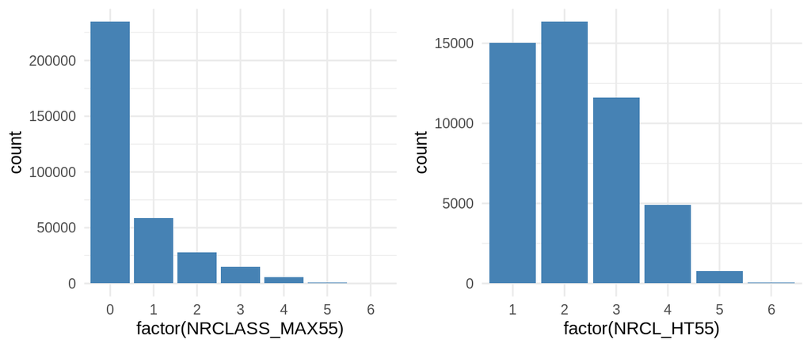

```r
p1 <- ggplot(df.55, aes(x=factor(NRCLASS_MAX55)))+
  geom_bar(stat="count",  fill="steelblue") +
  theme_minimal() +
  scale_x_discrete(na.translate = FALSE)


p2 <- ggplot(df.55, aes(x=factor(NRCL_HT55)))+
  geom_bar(stat="count",  fill="steelblue") +
  theme_minimal() +
  scale_x_discrete(na.translate = FALSE)

ggarrange(p1,p2)
```

```r
table(df.55$NRCL_HT55)
```

```
##
##     1     2     3     4     5     6
## 15045 16339 11622  4893   762    60
```

**Outcomes before AGE 55 and covariates after AGE 55 removed**

```r
#Drug purchase registry starts at 1994 - let's remove outcome event's before that.

df.55 <- df.55 %>%
  filter(!is.na(FU_END_AGE) & FU_END_AGE >= 0) %>% #Now removed (at earlier step just set as NA)

  mutate(across(all_of(unlist(names_ep)), #Outcome events before YEAR 1994 set as NA
                ~if_else(!is.na(get(str_glue("{cur_column()}_YEAR"))) &  get(str_glue("{cur_column()}_YEAR")) < 1994,
                         NA_integer_, .) ),

         across(all_of(unlist(names_ep)), #Outcome events before AGE 55 set as NA -> new variable {outcome}_POST
                list(POST=~if_else(get(str_glue("{cur_column()}_AGE")) < 55,
                                   NA_integer_, .) )),


         across(all_of(covs_nfem), #Covariates _after_ AGE 55 set as NA -> new variable {cov}_PRE
                list(PRE=~if_else( get(str_glue("{cur_column()}_AGE")) >= 55, 0L, as.integer(.)) ))

  )%>%
  mutate_at("NRCL_HT55", as.factor)


#         across(all_of(unlist(names_ep)), #If {outcome}_POST is NA, also corresponding AGE variable is set as NA
 #               list(POST_AGE =~if_else(    is.na(get(str_glue("{cur_column()}_POST"))),
  #                                     NA_real_, get(str_glue("{cur_column()}_AGE")) ))),


#Each outcome is filtered separately - for cox-model
# df.55.list <- lapply(names_ep, function(ep){

#      df.55 %>% filter(get(str_glue("{ep}_AGE")) >=55)

#  }) %>% setNames(names_ep)


#Filter if no hypertension, no medication or age above 55
df.55.all <- df.55
df.55 <- df.55 %>% filter(!is.na(NRCL_HT55))
```

**Summaries for outcomes**

```r
lapply(names_ep, function(ep){
    df.55 %>%
       select(str_glue("{ep}_AGE"), ep, str_glue("{ep}_POST"))  %>%
       mutate_at(c(ep, str_glue("{ep}_POST")), as.factor) %>%
       summary()
  }) %>% setNames(names_ep)
```

```
## $CVD_HARD
##   CVD_HARD_AGE   CVD_HARD     CVD_HARD_POST
##  Min.   : 0.15   0   :36798   0   :29154
##  1st Qu.:54.83   1   :11233   1   : 7166
##  Median :62.94   NA's:  690   NA's:12401
##  Mean   :61.71
##  3rd Qu.:69.94
##  Max.   :82.52
##
## $CHD
##     CHD_AGE        CHD        CHD_POST
##  Min.   : 0.15   0   :40046   0   :32021
##  1st Qu.:55.60   1   : 8190   1   : 5294
##  Median :63.60   NA's:  485   NA's:11406
##  Mean   :62.33
##  3rd Qu.:70.52
##  Max.   :81.94
##
## $HEARTFAIL
##  HEARTFAIL_AGE   HEARTFAIL    HEARTFAIL_POST
##  Min.   : 0.01   0   :43690   0   :35468
##  1st Qu.:56.84   1   : 4803   1   : 3301
##  Median :64.61   NA's:  228   NA's: 9952
##  Mean   :63.12
##  3rd Qu.:71.20
##  Max.   :82.58
##
## $STR_EXH
##   STR_EXH_AGE    STR_EXH      STR_EXH_POST
##  Min.   : 0.63   0   :42147   0   :34097
##  1st Qu.:57.11   1   : 3978   1   : 2766
##  Median :64.86   NA's: 2596   NA's:11858
##  Mean   :63.37
##  3rd Qu.:71.39
##  Max.   :82.81
##
## $INTRACRA
##   INTRACRA_AGE   INTRACRA     INTRACRA_POST
##  Min.   : 2.46   0   :42388   0   :34391
##  1st Qu.:57.62   1   :  997   1   :  582
```

[output cut: 16 more lines]

```
##  Min.   : 2.46   0:45587   0   :37278
##  1st Qu.:57.93   1: 3134   1   : 2763
##  Median :65.60             NA's: 8680
##  Mean   :64.06
##  3rd Qu.:71.91
##  Max.   :81.94
##
## $K_CARDIAC
##  K_CARDIAC_AGE   K_CARDIAC K_CARDIAC_POST
##  Min.   : 2.46   0:47157   0   :38653
##  1st Qu.:57.93   1: 1564   1   : 1388
##  Median :65.60             NA's: 8680
##  Mean   :64.06
##  3rd Qu.:71.91
##  Max.   :81.94
```

## 1.5 Characteristics

**Number of drug classes**

```r
htres_pre55_long %>%
  #slice(1:10000) %>%
  select(FINNGENID, sum_nr_class, sum_classes) %>%
  #Highest number of classes selected
  group_by(FINNGENID) %>%
    slice(which.max(sum_nr_class)) %>%
  ungroup()  %>%
  #sum_classes converted to vector and arranged alphabetically
  mutate(sum_classes = str_split(sum_classes,"\\|"),
         sum_classes = lapply(sum_classes, sort)) %>%
  #Grouped by sum_clases and number of each combination selected
  group_by(sum_classes) %>%
    summarise(n=n()) %>%
  ungroup %>%
  #Pecentage calculated
  mutate(perc=round(n/sum(n)*100,2)) %>%
  #Format changes and ordering
  rowwise %>%
    mutate(sum_classes =  glue::glue_collapse(sum_classes, sep=", ")) %>%
  ungroup() %>%
  arrange(desc(n)) %>%
  rename(class_combinations = sum_classes) %>%
  filter(n>=5) %>%
  my.kable() %>%
  kable_styling(font_size = 12, full_width=F, position="left")
```

| class_combinations | n | perc |
| --- | --- | --- |
| BB | 36975 | 33.22 |
| ARB | 7225 | 6.49 |
| ACEI | 6164 | 5.54 |
| diuretic | 5333 | 4.79 |
| CCB | 4903 | 4.40 |
| ACEI, BB | 4216 | 3.79 |
| BB, CCB | 3959 | 3.56 |
| ARB, BB | 3633 | 3.26 |
| ARB, diuretic | 3582 | 3.22 |
| BB, diuretic | 3277 | 2.94 |
| ACEI, diuretic | 3030 | 2.72 |
| ACEI, BB, diuretic | 2569 | 2.31 |
| ARB, BB, diuretic | 2417 | 2.17 |
| ARB, CCB, diuretic | 2369 | 2.13 |
| ACEI, CCB | 2156 | 1.94 |
| ARB, BB, CCB, diuretic | 2102 | 1.89 |
| ARB, CCB | 2050 | 1.84 |
| ACEI, BB, CCB | 1888 | 1.70 |
| ACEI, BB, CCB, diuretic | 1794 | 1.61 |
| ACEI, ARB | 1631 | 1.47 |
| ACEI, CCB, diuretic | 1525 | 1.37 |
| ARB, BB, CCB | 1381 | 1.24 |
| BB, CCB, diuretic | 1124 | 1.01 |
| ACEI, ARB, diuretic | 894 | 0.80 |
| CCB, diuretic | 610 | 0.55 |
| ACEI, ARB, BB | 593 | 0.53 |
| ACEI, ARB, BB, diuretic | 509 | 0.46 |
| ACEI, ARB, CCB, diuretic | 497 | 0.45 |
| ACEI, ARB, CCB | 451 | 0.41 |
| ACEI, ARB, BB, CCB, diuretic | 414 | 0.37 |
| ACEI, ARB, BB, CCB | 305 | 0.27 |
| other | 257 | 0.23 |
| ARB, BB, CCB, diuretic, other | 221 | 0.20 |
| ACEI, BB, CCB, diuretic, other | 120 | 0.11 |
| BB, other | 118 | 0.11 |
| ARB, BB, CCB, other | 106 | 0.10 |
| ACEI, BB, CCB, other | 95 | 0.09 |
| ARB, CCB, diuretic, other | 84 | 0.08 |
| ARB, BB, diuretic, other | 73 | 0.07 |
| BB, CCB, other | 68 | 0.06 |
| ACEI, ARB, BB, CCB, diuretic, other | 61 | 0.05 |
| BB, diuretic, other | 55 | 0.05 |
| ACEI, CCB, diuretic, other | 47 | 0.04 |
| ARB, diuretic, other | 38 | 0.03 |
| ACEI, ARB, BB, CCB, other | 38 | 0.03 |
| diuretic, other | 34 | 0.03 |
| CCB, other | 31 | 0.03 |
| ACEI, BB, diuretic, other | 30 | 0.03 |
| ACEI, diuretic, other | 28 | 0.03 |
| ACEI, BB, other | 28 | 0.03 |
| ACEI, CCB, other | 26 | 0.02 |
| ACEI, ARB, BB, diuretic, other | 25 | 0.02 |
| ARB, CCB, other | 23 | 0.02 |
| BB, CCB, diuretic, other | 22 | 0.02 |
| ACEI, ARB, CCB, diuretic, other | 21 | 0.02 |
| ACEI, other | 17 | 0.02 |
| ARB, other | 16 | 0.01 |
| ARB, BB, other | 13 | 0.01 |
| ACEI, ARB, BB, other | 13 | 0.01 |
| CCB, diuretic, other | 9 | 0.01 |
| ACEI, ARB, CCB, other | 8 | 0.01 |
| ACEI, ARB, diuretic, other | 7 | 0.01 |

```r
#One line removed, because n<5.
```

**Number of individuals** Here hypertensive individuals have hypertension diagnosis, at least one medication and no history of outcome before age 55.

```r
font_size <- 12

#Hypertension
df.55.all %>%
  mutate(HT_TMP = if_else(is.na(NRCL_HT55) | as.numeric(NRCL_HT55) == 0, 0L, 1L)) %>%
  summarise(n=n(), ht_n = sum(HT_TMP, na.rm=T), ht_p = round(mean(HT_TMP, na.rm=T)*100,2))%>%
  my.kable() %>%
  kable_styling(font_size = font_size, full_width=F, position="left")
```

| n | ht_n | ht_p |
| --- | --- | --- |
| 342499 | 48721 | 14.23 |

### 1.5.1 Number of medicine classes

```r
#Number of medicine classes
df.55 %>%
  create_n_table2("NRCL5_HT55", c(covs_pre, unlist(names_ep_post))) %>%
  mutate_all(~str_replace(.,"^[0-4]\\s.*$", "-")) %>%
  my.kable() %>%   kable_styling(font_size = font_size)
```

| NRCL5_HT55 | 1 | 2 | 3 | 4 | 5+ | P-value |
| --- | --- | --- | --- | --- | --- | --- |
| n | 15045 | 16339 | 11622 | 4893 | 822 | NA |
| female | 8140 (54.1%) | 8844 (54.1%) | 5964 (51.3%) | 2094 (42.8%) | 273 (33.2%) | <2e-16 |
| DIABETES_PRE | 2052 (13.6%) | 3101 (19%) | 3169 (27.3%) | 1836 (37.5%) | 458 (55.7%) | <2e-16 |
| OBESITY_PRE | 690 (4.6%) | 1232 (7.5%) | 1332 (11.5%) | 755 (15.4%) | 151 (18.4%) | <2e-16 |
| HYPCHOL_WIDE_PRE | 3295 (21.9%) | 5136 (31.4%) | 4898 (42.1%) | 2559 (52.3%) | 537 (65.3%) | <2e-16 |
| CVD_HARD_POST | 2892 (23.2%) | 2288 (18.6%) | 1379 (17.2%) | 516 (16.6%) | 91 (20.1%) | <2e-16 |
| CHD_POST | 2119 (16.7%) | 1674 (13.3%) | 1017 (12.2%) | 410 (12.7%) | 74 (15.4%) | <2e-16 |
| HEARTFAIL_POST | 1277 (9.7%) | 1066 (8.1%) | 648 (7.5%) | 278 (8.3%) | 32 (6.7%) | 1.18e-08 |
| STR_EXH_POST | 1101 (9%) | 885 (7.1%) | 549 (6.5%) | 201 (6.1%) | 30 (6%) | 1.12e-13 |
| INTRACRA_POST | 234 (2%) | 190 (1.6%) | 104 (1.3%) | 46 (1.5%) | 8 (1.7%) | 0.00207 |
| RENFAIL_POST | 838 (6.3%) | 826 (6.2%) | 646 (7.3%) | 318 (9.2%) | 49 (10%) | 4.24e-11 |
| DEATH_POST | 1019 (7.7%) | 881 (6.5%) | 580 (6.4%) | 244 (6.7%) | 39 (7%) | 0.000665 |
| K_CARDIAC_POST | 484 (3.6%) | 436 (3.2%) | 324 (3.6%) | 127 (3.5%) | 17 (3.1%) | 0.425 |

### 1.5.2 Resistant hypertension

```r
#Number of resistant and refractive hypertension
df.55 %>%
  create_n_table2("RES2_HT55", c(covs_pre, unlist(names_ep_post))) %>%
  my.kable() %>%   kable_styling(font_size = font_size)
```

| RES2_HT55 | Mild | Resistant | P-value |
| --- | --- | --- | --- |
| n | 15045 | 5715 | NA |
| female | 8140 (54.1%) | 2367 (41.4%) | <2e-16 |
| DIABETES_PRE | 2052 (13.6%) | 2294 (40.1%) | <2e-16 |
| OBESITY_PRE | 690 (4.6%) | 906 (15.9%) | <2e-16 |
| HYPCHOL_WIDE_PRE | 3295 (21.9%) | 3096 (54.2%) | <2e-16 |
| CVD_HARD_POST | 2892 (23.2%) | 607 (17%) | 3.66e-15 |
| CHD_POST | 2119 (16.7%) | 484 (13%) | 8.18e-08 |
| HEARTFAIL_POST | 1277 (9.7%) | 310 (8.1%) | 0.00197 |
| STR_EXH_POST | 1101 (9%) | 231 (6.1%) | 8.7e-09 |
| INTRACRA_POST | 234 (2%) | 54 (1.5%) | 0.0443 |
| RENFAIL_POST | 838 (6.3%) | 367 (9.3%) | 2.05e-10 |
| DEATH_POST | 1019 (7.7%) | 283 (6.8%) | 0.0526 |
| K_CARDIAC_POST | 484 (3.6%) | 144 (3.4%) | 0.562 |

# 2 Analysis

## 2.1 KM plots

**Model by survfit**

```r
font_size <- 11

kms.c <-
  lapply(names_ep, function(ep){
    survfit(Surv(get(str_glue("{ep}_AGE")), get(str_glue("{ep}_POST"))) ~ NRCL5_HT55, data=df.55)
  }) %>% setNames(names_ep)


kms.r <-
  lapply(names_ep, function(ep){
    survfit(Surv(get(str_glue("{ep}_AGE")), get(str_glue("{ep}_POST"))) ~ RES2_HT55, data=df.55)
  }) %>% setNames(names_ep)
```

### 2.1.1 Number of medicine classes

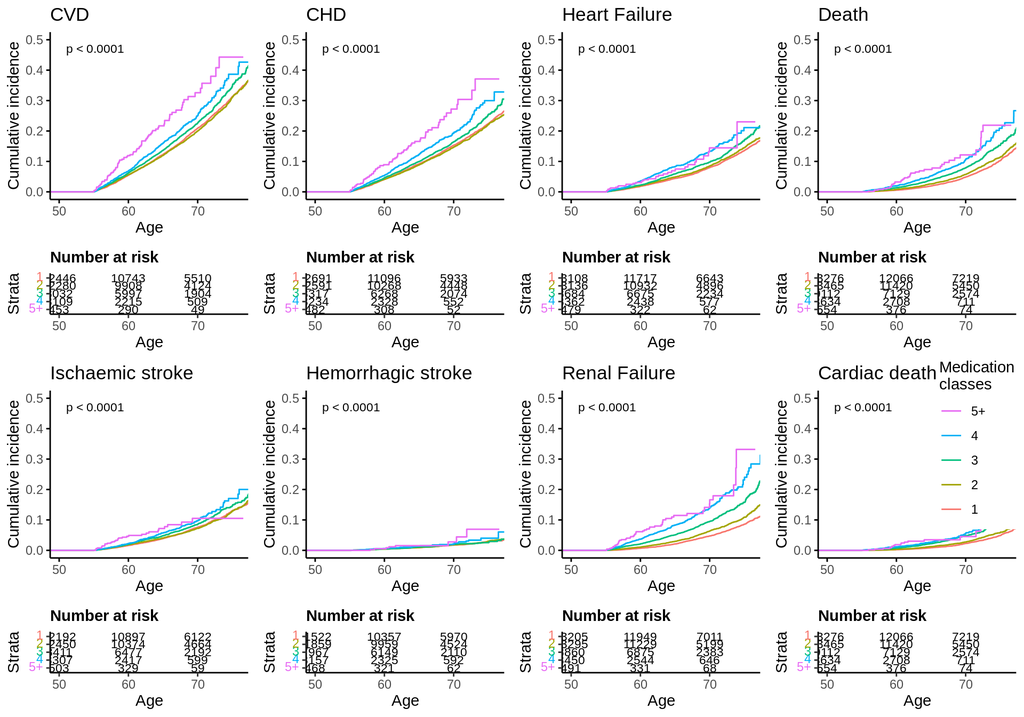

```r
legs_nr_cl <- c("1","2","3","4","5+")
names_ep_tmp <- list("CVD_HARD", "STR_EXH", "CHD", "INTRACRA", "HEARTFAIL", "RENFAIL", "DEATH", "K_CARDIAC")
ep<- names_ep_tmp[[1]]

plot_list.c <- lapply(names_ep_tmp, function(ep){
    survplot <- ggsurvplot(kms.c[[ep]], fun="event", conf.int = F, censor = F,
                           pval=T, pval.coord = c(51,0.47), pval.size=3,
                           xlim=c(50,76), ylim=c(0, 0.5), break.x.by=10,
                           xlab="Age", ylab="Cumulative incidence",
                           title = nice_names[ep],  size = 0.5, ggtheme = theme_classic(),
                           legend.labs=legs_nr_cl, legend="none",
                           risk.table=T, fontsize=3, risk.table.height=0.32)
    survplot$table <- survplot$table +
              theme(plot.title = element_text(size=11, face="bold"))
    survplot
  })  %>% setNames(names_ep_tmp)


plot_list.c$K_CARDIAC$plot <-  plot_list.c$K_CARDIAC$plot +
      theme(legend.position = c(0.8,0.7)) +
      guides(col = guide_legend(reverse = TRUE, title = 'Medication\nclasses'))


plots.c <- arrange_ggsurvplots(plot_list.c, nrow = 2, ncol = 4)
```

```r
ggsave(file = str_glue("{fig_path}/km.c.png"), plot = plots.c, height = 9, width = 12, dpi = 200)
ggsave(file = str_glue("{fig_path}/km.c.eps"), plot = plots.c, height = 9, width = 12, dpi = 200, device = cairo_ps,)
```

### 2.1.2 Resistant hypertension

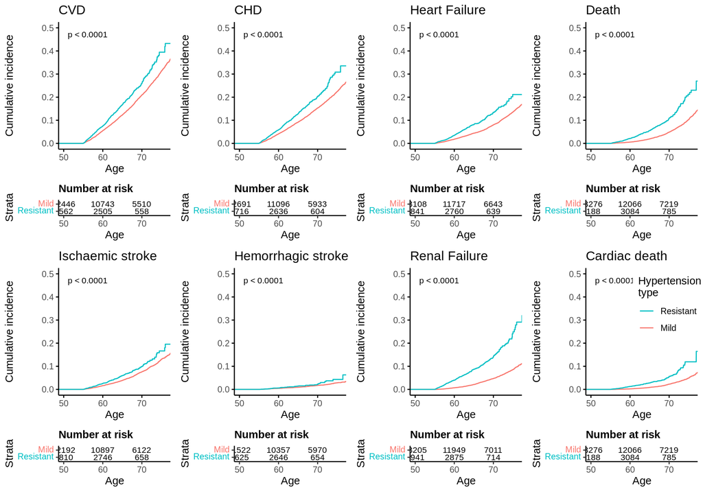

```r
legs_res_ht <- levels(df.55$RES2_HT55)

plot_list.r <- lapply(names_ep_tmp, function(ep){
    survplot <- ggsurvplot(kms.r[[ep]], fun="event", conf.int = F, censor = F,
                           pval=T, pval.coord = c(51,0.47), pval.size=3,
                           xlim=c(50,76), ylim=c(0, 0.5), break.x.by=10,
                           xlab="Age", ylab="Cumulative incidence",
                           title = nice_names[ep],  size = 0.5, ggtheme = theme_classic(),
                           legend.labs=legs_res_ht, legend="none",
                           risk.table=T, fontsize=3, risk.table.height=0.27)
    survplot$table <- survplot$table +
              theme(plot.title = element_text(size=11, face="bold"))
    survplot
  })  %>% setNames(names_ep_tmp)


plot_list.r$K_CARDIAC$plot <-  plot_list.r$K_CARDIAC$plot +
      theme(legend.position = c(0.75,0.7)) +
      guides(col = guide_legend(reverse = TRUE, title = 'Hypertension\ntype'))


plots.r <- arrange_ggsurvplots(plot_list.r, nrow = 2, ncol = 4)
```

```r
ggsave(file = str_glue("{fig_path}/km.r.png"), plot = plots.r, height = 8, width = 12, dpi = 200)
ggsave(file = str_glue("{fig_path}/km.r.eps"), plot = plots.r, height = 8, width = 12, dpi = 200, device = cairo_ps,)
```

## 2.2 Cox plots

**Cox models calculated**

```r
covs_f_pre<- paste(covs_pre, collapse = " + ")

cxs.c <-
  lapply(names_ep, function(ep){
    my_formula <- str_glue("Surv({ep}_AGE, {ep}_POST) ~ NRCL5_HT55 + {covs_f_pre}")
    coxph(as.formula(my_formula), data= df.55)
  }) %>% setNames(names_ep)

#cxs.c

df.55 <- df.55 %>% mutate_at("NRCL_HT55", as.integer)
cxs.cn <-
  lapply(names_ep, function(ep){
    my_formula <- str_glue("Surv({ep}_AGE, {ep}_POST) ~ NRCL_HT55 + {covs_f_pre}")
    coxph(as.formula(my_formula), data= df.55)
  }) %>% setNames(names_ep)


cxs.r <-
  lapply(names_ep, function(ep){
    my_formula <- str_glue("Surv({ep}_AGE, {ep}_POST) ~ RES2_HT55 + {covs_f_pre}")
    coxph(as.formula(my_formula), data= df.55)
  }) %>% setNames(names_ep)

#cxs.r
```

**Assumptions**

Assumptions are tested for ‘number of medicine classes’ as exposure.

**cloglog plot**

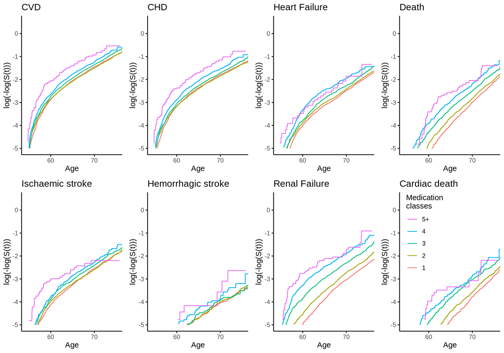

```r
plot_list.clog <- lapply(names_ep_tmp, function(ep){
    ggsurvplot(kms.c[[ep]], fun="cloglog", conf.int = F, censor = F,
                           pval.coord = c(51,0.47), pval.size=3,
                           xlim=c(55,76), ylim=c(-5,0.5),xlab="Age",
                           title = nice_names[ep],  size = 0.5, ggtheme = theme_classic(),
                           legend.labs=legs_nr_cl, legend="none")
  })  %>% setNames(names_ep_tmp)


plot_list.clog$K_CARDIAC$plot <-  plot_list.clog$K_CARDIAC$plot +
      theme(legend.position = c(0.25, 0.7)) +
      guides(col = guide_legend(reverse = TRUE, title = 'Medication\nclasses'))

plots.clog <- arrange_ggsurvplots(plot_list.clog, nrow = 2, ncol = 4)
```

```r
ggsave(file = str_glue("{fig_path}/clog.55.png"), plot = plots.clog, height = 8, width = 12, dpi = 200)
ggsave(file = str_glue("{fig_path}/clog.55.eps"), plot = plots.clog, height = 8, width = 12, dpi = 200, device = cairo_ps)
```

**Goodness of fit**

Cox-Snell residual is calculated from martingale residual. Then the Cox-Snell residual is used as pseudo observation times to fit a null Cox model to obtain cumulative hazard. Slope should be approximately 45 degrees (fit dashed line).

```r
names_ep_tmp <- list("CVD_HARD", "CHD","HEARTFAIL", "DEATH", "STR_EXH", "INTRACRA",  "RENFAIL",  "K_CARDIAC")

plot_list.cxsnl <- lapply(names_ep_tmp, function(ep){
  my.coxsnell.plot(cxs.c[[ep]], str_glue("{ep}_POST"), df.55, title=nice_names[ep])
})  %>% setNames(names_ep_tmp)

plots.cxsnl <- grid.arrange(grobs = plot_list.cxsnl, nrow=2, ncol = 4)
ggsave(file = str_glue("{fig_path}/coxsnell.55.png"), plot = plots.cxsnl, height = 5, width = 10, dpi = 200)
ggsave(file = str_glue("{fig_path}/coxsnell.55.eps"), plot = plots.cxsnl, height = 5, width = 10, dpi = 200, device = cairo_ps)
#Individual images are adjusted separately
```

**Influential observations**

```r
names_ep_tmp <- list("CVD_HARD", "CHD", "STR_EXH", "INTRACRA", "HEARTFAIL",  "RENFAIL",  "DEATH", "K_CARDIAC")
plot_list.dfbetas <- lapply(names_ep_tmp, function(ep){
  ggcoxdiagnostics(cxs.c[[ep]], type="dfbetas", title=nice_names[ep])
})  %>% setNames(names_ep_tmp)

plots.dfbetas <- grid.arrange(grobs = plot_list.dfbetas, nrow=4, ncol = 2)
ggsave(file = str_glue("{fig_path}/dfbetas.55.png"), plot = plots.dfbetas, height = 20, width = 12, dpi = 300)
#ggsave(file = str_glue("{fig_path}/dfbetas.55.eps"), plot = plots.dfbetas, height = 9, width = 12, dpi = 300,  device = cairo_ps)
#Individual images are adjusted separately
```

**Linearity**

We treat count variable NRCL_HT55 as continuous variable. Other variables are categorical.

```r
names_ep_tmp <- list("CVD_HARD", "CHD","HEARTFAIL", "DEATH", "STR_EXH", "INTRACRA",  "RENFAIL",  "K_CARDIAC")
plot_list.mrtg <- lapply(names_ep_tmp, function(ep){
    #my_formula <- str_glue("Surv({ep}_AGE, {ep}_POST) ~ NRCL_HT55 + log(NRCL_HT55) + sqrt(NRCL_HT55)")
    my_formula <- str_glue("Surv({ep}_AGE, {ep}_POST) ~ NRCL_HT55")
    plots <- ggcoxfunctional(as.formula(my_formula), data=df.55, font.x=9, font.tickslab=9)
    grid.arrange(grobs = plots, nrow=1, ncol = 1, top=text_grob(nice_names[ep], x=0.17, hjust=0))
})  %>% setNames(names_ep_tmp)
plots.mrtg <- grid.arrange(grobs = plot_list.mrtg, nrow=2, ncol =4)
ggsave(file = str_glue("{fig_path}/martingales.55.png"), plot = plots.mrtg, height =5, width = 10, dpi = 200)
ggsave(file = str_glue("{fig_path}/martingales.55.eps"), plot = plots.mrtg, height = 5, width = 10, dpi = 200, device = cairo_ps)
```

**Tables**

```r
removed_cols <- c("CHD.Variable", "STR_EXH.Variable", "INTRACRA.Variable", "HEARTFAIL.Variable", "RENFAIL.Variable", "DEATH.Variable", "K_CARDIAC.Variable")
#names_ep_post <- lapply(names_ep, function(ep){str_glue("{ep}_POST")})

#Number of drug classes
lapply(names_ep, function(ep){
  extr_table(cxs.c[[ep]], "NRCL") %>%
  select(-pval)
})%>% setNames(names_ep) %>%
  do.call(cbind,.)  %>%
  select(-one_of(removed_cols)) %>%
  mutate_all(as.character) %>%
  my.kable() %>%   kable_styling(font_size = font_size)
```

| CVD_HARD.Variable | CVD_HARD.HR | CHD.HR | HEARTFAIL.HR | STR_EXH.HR | INTRACRA.HR | RENFAIL.HR | DEATH.HR | K_CARDIAC.HR |
| --- | --- | --- | --- | --- | --- | --- | --- | --- |
| NRCL5_HT552 | 0.97 (0.92-1.02) | 0.95 (0.89-1.01) | 1.06 (0.97-1.15) | 1 (0.91-1.09) | 1.02 (0.84-1.24) | 1.25 (1.13-1.38) | 1.14 (1.04-1.25) | 1.19 (1.04-1.35) |
| NRCL5_HT553 | 1.04 (0.97-1.11) | 1 (0.92-1.08) | 1.18 (1.07-1.3) | 1.13 (1.01-1.25) | 1.06 (0.84-1.34) | 1.77 (1.59-1.97) | 1.42 (1.28-1.58) | 1.62 (1.4-1.88) |
| NRCL5_HT554 | 1.07 (0.97-1.17) | 1.07 (0.96-1.19) | 1.46 (1.28-1.67) | 1.18 (1.01-1.37) | 1.38 (0.99-1.91) | 2.36 (2.06-2.71) | 1.69 (1.46-1.96) | 1.71 (1.39-2.1) |
| NRCL5_HT555+ | 1.37 (1.11-1.69) | 1.35 (1.07-1.71) | 1.17 (0.82-1.66) | 1.27 (0.88-1.84) | 1.86 (0.91-3.79) | 2.5 (1.86-3.35) | 1.9 (1.37-2.62) | 1.53 (0.94-2.5) |

```r
#Number of drug classes/numeric
lapply(names_ep, function(ep){
  extr_table(cxs.cn[[ep]], "NRCL") %>%
  select(-pval)
})%>% setNames(names_ep) %>%
  do.call(cbind,.)  %>%
  select(-one_of(removed_cols)) %>%
  mutate_all(as.character) %>%
  my.kable() %>%   kable_styling(font_size = font_size)
```

| CVD_HARD.Variable | CVD_HARD.HR | CHD.HR | HEARTFAIL.HR | STR_EXH.HR | INTRACRA.HR | RENFAIL.HR | DEATH.HR | K_CARDIAC.HR |
| --- | --- | --- | --- | --- | --- | --- | --- | --- |
| NRCL_HT55 | 1.03 (1-1.05) | 1.02 (0.99-1.05) | 1.1 (1.06-1.14) | 1.06 (1.02-1.1) | 1.09 (1-1.19) | 1.32 (1.27-1.37) | 1.19 (1.14-1.24) | 1.21 (1.15-1.28) |

```r
#Resistant hypertension
lapply(names_ep, function(ep){
  extr_table(cxs.r[[ep]], "RES2_HT") %>%
  select(-pval)
})%>% setNames(names_ep) %>%
  do.call(cbind,.)  %>%
  select(-one_of(removed_cols)) %>%
  mutate_all(as.character) %>%
  my.kable() %>%   kable_styling(font_size = font_size)
```

| CVD_HARD.Variable | CVD_HARD.HR | CHD.HR | HEARTFAIL.HR | STR_EXH.HR | INTRACRA.HR | RENFAIL.HR | DEATH.HR | K_CARDIAC.HR |
| --- | --- | --- | --- | --- | --- | --- | --- | --- |
| RES2_HT55Resistant | 1.1 (1-1.21) | 1.1 (0.99-1.23) | 1.42 (1.24-1.63) | 1.21 (1.03-1.41) | 1.49 (1.08-2.05) | 2.3 (2-2.65) | 1.76 (1.52-2.04) | 1.79 (1.45-2.21) |

### 2.2.1 Number of medicine classes

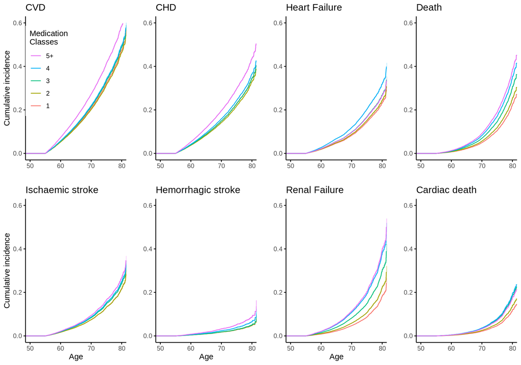

```r
names_ep_tmp <- list("CVD_HARD", "CHD","HEARTFAIL", "DEATH", "STR_EXH", "INTRACRA",  "RENFAIL",  "K_CARDIAC")

legs_nr_cl <- c("1","2","3","4","5+")
#names_ep_3 <- list("CVD_HARD","CHD", "RENFAIL")

#Covariate combinations
exp.covs <- expand.grid(
      female = 0.5,
      DIABETES_PRE = mean( df.55$DIABETES_PRE, na.rm=T),
      OBESITY_PRE = mean(df.55$OBESITY_PRE, na.rm=T),
      HYPCHOL_WIDE_PRE = mean( df.55$OBESITY_PRE, na.rm=T)
    )

fit.cxs.c <-
  lapply(names_ep_tmp, function(ep){

    exp.var <- expand.grid(NRCL5_HT55 = legs_nr_cl)
    exp.cxs <- bind_cols(exp.var, exp.covs)
    survfit(cxs.c[[ep]], newdata = exp.cxs)

  }) %>% setNames(names_ep_tmp)


plot_list.c <- lapply(names_ep_tmp, function(ep){

  ggsurvplot(fit.cxs.c[[ep]], fun="event", data= df.55, conf.int = F, censor = F, xlim=c(50,80), ylim=c(0,0.6),
             title = nice_names[[ep]],  size = 0.5, ggtheme = theme_classic(), legend.labs=legs_nr_cl,
             legend="none", break.x.by=10, xlab=" ", ylab=" ")$plot
})  %>% setNames(names_ep_tmp)

#Individual images are adjusted separately

plot_list.c$CVD_HARD <-  plot_list.c$CVD_HARD +
      ylab("Cumulative incidence") +
      theme(legend.position = c(0.23,0.62)) +
      guides(col = guide_legend(reverse = TRUE, title = 'Medication\nClasses'))

plot_list.c$STR_EXH <-  plot_list.c$STR_EXH +
  xlab("Age") + ylab("Cumulative incidence")

plot_list.c$INTRACRA <-  plot_list.c$INTRACRA +
  xlab("Age")

plot_list.c$RENFAIL <-  plot_list.c$RENFAIL +
  xlab("Age")


plots.c <- grid.arrange(grobs = plot_list.c, nrow=2, ncol = 4)
```

```r
ggsave(file = str_glue("{fig_path}/cx.medcl.55.png"), plot = plots.c, height = 6, width = 12, dpi = 300)
ggsave(file = str_glue("{fig_path}/cx.medcl.55.eps"), plot = plots.c, device = cairo_ps, height = 6, width = 12, dpi = 300)
```

### 2.2.2 Resistant hypertension

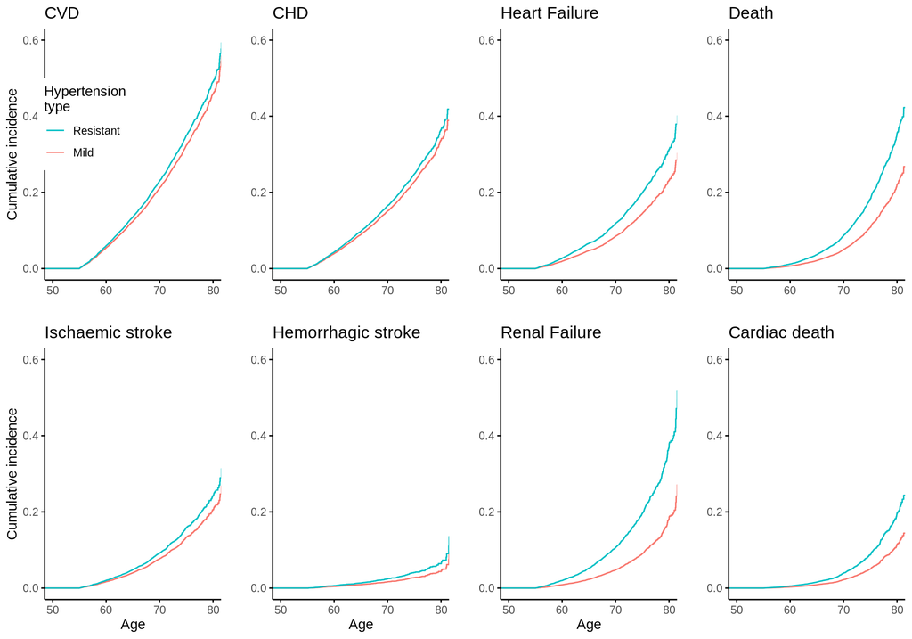

```r
fit.cxs.r <-
  lapply(names_ep_tmp, function(ep){

    exp.var <- expand.grid(RES2_HT55 = levels(as.factor( df.55$RES2_HT55)))
    exp.cxs <- bind_cols(exp.var, exp.covs)
    survfit(cxs.r[[ep]], newdata = exp.cxs)

  }) %>% setNames(names_ep_tmp)

plot_list.r <- lapply(names_ep_tmp, function(ep){

  ggsurvplot(fit.cxs.r[[ep]], fun="event", data= df.55, conf.int = F, censor = F, xlim=c(50,80), ylim=c(0,0.6),
             title = nice_names[[ep]],  size = 0.5, ggtheme = theme_classic(), legend.labs=levels( df.55$RES2_HT55),
             legend="none", break.x.by=10, xlab=" ", ylab=" ")$plot
})  %>% setNames(names_ep_tmp)

#Individual images are adjusted separately

plot_list.r$CVD_HARD <-  plot_list.r$CVD_HARD +
      ylab("Cumulative incidence") +
      theme(legend.position = c(0.23,0.62)) +
      guides(col = guide_legend(reverse = TRUE, title = 'Hypertension\ntype'))

plot_list.r$STR_EXH <-  plot_list.r$STR_EXH +
  xlab("Age") + ylab("Cumulative incidence")

plot_list.r$INTRACRA <-  plot_list.r$INTRACRA +
  xlab("Age")

plot_list.r$RENFAIL <-  plot_list.r$RENFAIL +
  xlab("Age")

plots.r <- grid.arrange(grobs = plot_list.r, nrow=2, ncol = 4)
```

```r
ggsave(file = str_glue("{fig_path}/cx.resht.55.png"), plot = plots.r, height = 6, width = 12, dpi = 300)
ggsave(file = str_glue("{fig_path}/cx.resht.55.eps"), plot = plots.r, device = cairo_ps, height = 6, width = 12, dpi = 300)
```

# 3 Additional analyses

## 3.1 Fine-Gray/death

Fine Gray models using death as competing risk

**New variables**

```r
#Creating the new variables.

names_ep_tmp <- list("CVD_HARD", "CHD","HEARTFAIL", "STR_EXH", "INTRACRA",  "RENFAIL")

df.55.fg <- df.55 %>% select("FINNGENID", contains("HT55"), all_of(c(covs_pre, unlist(names_ep_post), unlist(names_ep_age))))

#lapply(names_ep_tmp, function(ep){})
for (ep in unlist(names_ep_tmp)){
  df.55.fg <-   df.55.fg %>%
  mutate("{ep}.DEATH"     := if_else(get(str_glue("{ep}_POST")) == 1, get(str_glue("{ep}_POST")), as.integer(DEATH_POST*2))) %>%
  mutate("{ep}.DEATH_AGE" := if_else(get(str_glue("{ep}_POST")) == 1, get(str_glue("{ep}_AGE")),  DEATH_AGE)) %>%
  mutate("{ep}.DEATH"     := as.factor(get(str_glue("{ep}.DEATH")))) %>%
  mutate("{ep}.DEATH"     := recode(get(str_glue("{ep}.DEATH")), `0`="censor", `1`="event", `2`="death"))
}

df.55.fg %>% select(contains("DEATH")) %>%  mutate_if(is.integer, as.factor) %>% summary()
```

```
##  DEATH_POST     DEATH_AGE     CVD_HARD.DEATH CVD_HARD.DEATH_AGE  CHD.DEATH
##  0   :37278   Min.   : 2.46   censor:27890   Min.   :55.00      censor:30449
##  1   : 2763   1st Qu.:57.93   event : 7166   1st Qu.:61.17      event : 5294
##  NA's: 8680   Median :65.60   death : 1264   Median :66.46      death : 1572
##               Mean   :64.06   NA's  :12401   Mean   :66.63      NA's  :11406
##               3rd Qu.:71.91                  3rd Qu.:71.81
##               Max.   :81.94                  Max.   :82.52
##                                              NA's   :12401
##  CHD.DEATH_AGE   HEARTFAIL.DEATH HEARTFAIL.DEATH_AGE STR_EXH.DEATH
##  Min.   :55.00   censor:33620    Min.   :55.00       censor:32023
##  1st Qu.:61.44   event : 3301    1st Qu.:61.89       event : 2766
##  Median :66.78   death : 1848    Median :67.35       death : 2074
##  Mean   :66.90   NA's  : 9952    Mean   :67.28       NA's  :11858
##  3rd Qu.:72.19                   3rd Qu.:72.52
##  Max.   :81.94                   Max.   :82.58
##  NA's   :11406                   NA's   :9952
##  STR_EXH.DEATH_AGE INTRACRA.DEATH INTRACRA.DEATH_AGE RENFAIL.DEATH
##  Min.   :55.00     censor:32395   Min.   :55.00      censor:34438
##  1st Qu.:61.88     event :  582   1st Qu.:62.09      event : 2677
##  Median :67.31     death : 1996   Median :67.48      death : 2186
##  Mean   :67.27     NA's  :13748   Mean   :67.42      NA's  : 9420
##  3rd Qu.:72.50                    3rd Qu.:72.66
##  Max.   :82.81                    Max.   :82.93
##  NA's   :11858                    NA's   :13748
##  RENFAIL.DEATH_AGE
##  Min.   :55.00
##  1st Qu.:62.27
##  Median :67.66
##  Mean   :67.58
##  3rd Qu.:72.82
##  Max.   :82.20
##  NA's   :9420
```

Fine Gray models

```r
cxs.fg.c <-
  lapply(names_ep_tmp, function(ep){
    df.tmp <- df.55.fg %>%  filter(!is.na(get(str_glue("{ep}.DEATH"))))
    fg.data       <- finegray(as.formula(str_glue("Surv({ep}.DEATH_AGE, {ep}.DEATH) ~ .")), data=df.tmp, etype="event")
    fg.fit        <- coxph(as.formula(str_glue("Surv(fgstart, fgstop, fgstatus) ~ NRCL5_HT55 + {covs_f_pre}")), weight = fgwt, data=fg.data)

  }) %>% setNames(names_ep_tmp)

cxs.fg.cn <-
  lapply(names_ep_tmp, function(ep){
    df.tmp <- df.55.fg %>%  filter(!is.na(get(str_glue("{ep}.DEATH"))))
    fg.data       <- finegray(as.formula(str_glue("Surv({ep}.DEATH_AGE, {ep}.DEATH) ~ .")), data=df.tmp, etype="event")
    fg.fit        <- coxph(as.formula(str_glue("Surv(fgstart, fgstop, fgstatus) ~ NRCL_HT55 + {covs_f_pre}")), weight = fgwt, data=fg.data)

  }) %>% setNames(names_ep_tmp)

cxs.fg.r <-
  lapply(names_ep_tmp, function(ep){
    df.tmp <- df.55.fg %>%  filter(!is.na(get(str_glue("{ep}.DEATH"))))
    fg.data       <- finegray(as.formula(str_glue("Surv({ep}.DEATH_AGE, {ep}.DEATH) ~ .")), data=df.tmp, etype="event")
    fg.fit        <- coxph(as.formula(str_glue("Surv(fgstart, fgstop, fgstatus) ~ RES2_HT55 + {covs_f_pre}")), weight = fgwt, data=fg.data)

  }) %>% setNames(names_ep_tmp)
```

**Tables**

```r
removed_cols <- c("CHD.Variable", "STR_EXH.Variable", "INTRACRA.Variable", "HEARTFAIL.Variable", "RENFAIL.Variable")
#names_ep_post <- lapply(names_ep, function(ep){str_glue("{ep}_POST")})

#Number of drug classes
lapply(names_ep_tmp, function(ep){
  extr_table(cxs.fg.c[[ep]], "NRCL") %>%
  select(-pval)
})%>% setNames(names_ep_tmp) %>%
  do.call(cbind,.)  %>%
  select(-one_of(removed_cols)) %>%
  mutate_all(as.character) %>%
  my.kable() %>%   kable_styling(font_size = font_size)
```

| CVD_HARD.Variable | CVD_HARD.HR | CHD.HR | HEARTFAIL.HR | STR_EXH.HR | INTRACRA.HR | RENFAIL.HR |
| --- | --- | --- | --- | --- | --- | --- |
| NRCL5_HT552 | 0.96 (0.9-1.01) | 0.94 (0.88-1) | 1.04 (0.96-1.13) | 0.98 (0.89-1.07) | 1.01 (0.83-1.22) | 1.21 (1.1-1.33) |
| NRCL5_HT553 | 1.02 (0.95-1.08) | 0.97 (0.9-1.05) | 1.14 (1.03-1.25) | 1.08 (0.97-1.19) | 1.03 (0.81-1.3) | 1.66 (1.5-1.84) |
| NRCL5_HT554 | 1.02 (0.93-1.13) | 1.03 (0.92-1.14) | 1.39 (1.22-1.59) | 1.11 (0.95-1.29) | 1.31 (0.95-1.82) | 2.19 (1.92-2.5) |
| NRCL5_HT555+ | 1.32 (1.07-1.63) | 1.28 (1.02-1.62) | 1.11 (0.78-1.58) | 1.17 (0.81-1.7) | 1.76 (0.87-3.58) | 2.25 (1.68-3.01) |

```r
#Number of drug classes/numeric
lapply(names_ep_tmp, function(ep){
  extr_table(cxs.fg.cn[[ep]], "NRCL") %>%
  select(-pval)
})%>% setNames(names_ep_tmp) %>%
  do.call(cbind,.)  %>%
  select(-one_of(removed_cols)) %>%
  mutate_all(as.character) %>%
  my.kable() %>%   kable_styling(font_size = font_size)
```

| CVD_HARD.Variable | CVD_HARD.HR | CHD.HR | HEARTFAIL.HR | STR_EXH.HR | INTRACRA.HR | RENFAIL.HR |
| --- | --- | --- | --- | --- | --- | --- |
| NRCL_HT55 | 1.02 (0.99-1.04) | 1.01 (0.98-1.04) | 1.08 (1.05-1.12) | 1.04 (1-1.08) | 1.07 (0.98-1.17) | 1.28 (1.24-1.33) |

```r
#Resistant hypertension
lapply(names_ep_tmp, function(ep){
  extr_table(cxs.fg.r[[ep]], "RES2_HT") %>%
  select(-pval)
})%>% setNames(names_ep_tmp) %>%
  do.call(cbind,.)  %>%
  select(-one_of(removed_cols)) %>%
  mutate_all(as.character) %>%
  my.kable() %>%   kable_styling(font_size = font_size)
```

| CVD_HARD.Variable | CVD_HARD.HR | CHD.HR | HEARTFAIL.HR | STR_EXH.HR | INTRACRA.HR | RENFAIL.HR |
| --- | --- | --- | --- | --- | --- | --- |
| RES2_HT55Resistant | 1.06 (0.97-1.17) | 1.06 (0.95-1.18) | 1.36 (1.19-1.55) | 1.14 (0.98-1.33) | 1.43 (1.04-1.97) | 2.15 (1.87-2.46) |

## 3.2 Additional covariates

**Remove NA’s**

```r
dim(df.55)[1]
```

```
## [1] 48721
```

```r
df.55 %>% select(all_of(covs_extra)) %>% mutate_all(as.factor) %>% summary()
```

```
##  ALCOHOL_RELATED  SMOKED                 EDUC3
##  0:43627         0   :13393   secondary     :19610
##  1: 5094         1   :14893   post-secondary: 8721
##                  NA's:20435   higher        : 8122
##                               NA's          :12268
```

```r
df.55.nona <- df.55 %>%
  filter(!is.na(SMOKED))
dim(df.55.nona)[1]
```

```
## [1] 28286
```

```r
df.55.nona <- df.55.nona %>%
  filter(!is.na(EDUC3))
dim(df.55.nona)[1]
```

```
## [1] 20583
```

```r
df.55.nona %>% select(all_of(covs_extra)) %>% mutate_all(as.factor) %>% summary()
```

```
##  ALCOHOL_RELATED SMOKED               EDUC3
##  0:18370         0:10340   secondary     :11330
##  1: 2213         1:10243   post-secondary: 4837
##                            higher        : 4416
```

**Characteristics**

Number of medicine classes

```r
df.tmp <- df.55.nona %>%
  mutate( Secondary       = if_else(EDUC3=="secondary", 1L, 0L),
         `Post-secondary` = if_else(EDUC3=="post-secondary", 1L, 0L),
          Higher          = if_else(EDUC3=="higher", 1L, 0L))

covs.tmp <- c("ALCOHOL_RELATED", "SMOKED", "Secondary", "Post-secondary", "Higher")

#Number of medicine classes
df.tmp %>%
  create_n_table2("NRCL5_HT55", covs.tmp) %>%
  mutate_all(~str_replace(.,"^[0-4]\\s.*$", "-")) %>%
  my.kable() %>%   kable_styling(font_size = font_size)
```

| NRCL5_HT55 | 1 | 2 | 3 | 4 | 5+ | P-value |
| --- | --- | --- | --- | --- | --- | --- |
| n | 6197 | 6878 | 5075 | 2122 | 311 | NA |
| ALCOHOL_RELATED | 582 (9.4%) | 675 (9.8%) | 606 (11.9%) | 301 (14.2%) | 49 (15.8%) | 3.03e-12 |
| SMOKED | 2998 (48.4%) | 3384 (49.2%) | 2562 (50.5%) | 1133 (53.4%) | 166 (53.4%) | 0.000631 |
| Secondary | 3361 (54.2%) | 3758 (54.6%) | 2825 (55.7%) | 1201 (56.6%) | 185 (59.5%) | 0.115 |
| Post-secondary | 1430 (23.1%) | 1628 (23.7%) | 1189 (23.4%) | 517 (24.4%) | 73 (23.5%) | 0.804 |
| Higher | 1406 (22.7%) | 1492 (21.7%) | 1061 (20.9%) | 404 (19%) | 53 (17%) | 0.00143 |

Resistant hypertension

```r
#Number of resistant and refractive hypertension
df.tmp %>%
  create_n_table2("RES2_HT55", covs.tmp) %>%
  my.kable() %>%   kable_styling(font_size = font_size)
```

| RES2_HT55 | Mild | Resistant | P-value |
| --- | --- | --- | --- |
| n | 6197 | 2433 | NA |
| ALCOHOL_RELATED | 582 (9.4%) | 350 (14.4%) | 2.28e-11 |
| SMOKED | 2998 (48.4%) | 1299 (53.4%) | 3.09e-05 |
| Secondary | 3361 (54.2%) | 1386 (57%) | 0.0232 |
| Post-secondary | 1430 (23.1%) | 590 (24.2%) | 0.258 |
| Higher | 1406 (22.7%) | 457 (18.8%) | 8.21e-05 |

**Cox models calculated**

```r
covs_f_pre <- paste(covs_pre, collapse = " + ")
covs_f_extra <- paste(covs_extra, collapse = " + ")
#covs_f_extra <- "SMOKED + ALCOHOL_RELATED + SES"

cxs.c <-
  lapply(names_ep, function(ep){
    my_formula <- str_glue("Surv({ep}_AGE, {ep}_POST) ~ NRCL5_HT55 + {covs_f_pre} + {covs_f_extra}")
    coxph(as.formula(my_formula), data= df.55.nona)
  }) %>% setNames(names_ep)

#cxs.c

df.55.nona <- df.55.nona %>% mutate_at("NRCL_HT55", as.integer)
cxs.cn <-
  lapply(names_ep, function(ep){
    my_formula <- str_glue("Surv({ep}_AGE, {ep}_POST) ~ NRCL_HT55 + {covs_f_pre} + {covs_f_extra}")
    coxph(as.formula(my_formula), data= df.55.nona)
  }) %>% setNames(names_ep)


cxs.r <-
  lapply(names_ep, function(ep){
    my_formula <- str_glue("Surv({ep}_AGE, {ep}_POST) ~ RES2_HT55 + {covs_f_pre} + {covs_f_extra}")
    coxph(as.formula(my_formula), data= df.55.nona)
  }) %>% setNames(names_ep)

#cxs.r
```

**Tables**

```r
removed_cols <- c("CHD.Variable", "STR_EXH.Variable", "INTRACRA.Variable", "HEARTFAIL.Variable", "RENFAIL.Variable", "DEATH.Variable", "K_CARDIAC.Variable")
#names_ep_post <- lapply(names_ep, function(ep){str_glue("{ep}_POST")})

#Number of drug classes
lapply(names_ep, function(ep){
  extr_table(cxs.c[[ep]], "NRCL") %>%
  select(-pval)
})%>% setNames(names_ep) %>%
  do.call(cbind,.)  %>%
  select(-one_of(removed_cols)) %>%
  mutate_all(as.character) %>%
  my.kable() %>%   kable_styling(font_size = font_size)
```

| CVD_HARD.Variable | CVD_HARD.HR | CHD.HR | HEARTFAIL.HR | STR_EXH.HR | INTRACRA.HR | RENFAIL.HR | DEATH.HR | K_CARDIAC.HR |
| --- | --- | --- | --- | --- | --- | --- | --- | --- |
| NRCL5_HT552 | 0.91 (0.83-0.99) | 0.87 (0.78-0.97) | 1.08 (0.95-1.24) | 0.96 (0.83-1.1) | 0.97 (0.71-1.33) | 1.25 (1.07-1.46) | 1.22 (1.05-1.41) | 1.26 (1.02-1.57) |
| NRCL5_HT553 | 0.96 (0.87-1.07) | 0.95 (0.84-1.07) | 1.29 (1.1-1.5) | 1.03 (0.87-1.21) | 1.01 (0.69-1.48) | 1.65 (1.39-1.96) | 1.57 (1.33-1.86) | 1.64 (1.29-2.09) |
| NRCL5_HT554 | 0.99 (0.85-1.15) | 0.93 (0.78-1.11) | 1.51 (1.22-1.86) | 1.22 (0.98-1.54) | 1.38 (0.83-2.3) | 1.99 (1.6-2.48) | 1.94 (1.56-2.42) | 2 (1.46-2.73) |
| NRCL5_HT555+ | 1.01 (0.69-1.49) | 0.79 (0.49-1.27) | 1.01 (0.54-1.9) | 1.32 (0.73-2.36) | 1.35 (0.33-5.57) | 2.15 (1.32-3.5) | 1.37 (0.73-2.59) | 1.25 (0.51-3.09) |

```r
#Number of drug classes/numeric
lapply(names_ep, function(ep){
  extr_table(cxs.cn[[ep]], "NRCL") %>%
  select(-pval)
})%>% setNames(names_ep) %>%
  do.call(cbind,.)  %>%
  select(-one_of(removed_cols)) %>%
  mutate_all(as.character) %>%
  my.kable() %>%   kable_styling(font_size = font_size)
```

| CVD_HARD.Variable | CVD_HARD.HR | CHD.HR | HEARTFAIL.HR | STR_EXH.HR | INTRACRA.HR | RENFAIL.HR | DEATH.HR | K_CARDIAC.HR |
| --- | --- | --- | --- | --- | --- | --- | --- | --- |
| NRCL_HT55 | 0.99 (0.95-1.03) | 0.97 (0.93-1.02) | 1.12 (1.06-1.19) | 1.05 (0.98-1.11) | 1.06 (0.92-1.22) | 1.26 (1.18-1.34) | 1.23 (1.16-1.3) | 1.24 (1.13-1.35) |

```r
#Resistant hypertension
lapply(names_ep, function(ep){
  extr_table(cxs.r[[ep]], "RES2_HT") %>%
  select(-pval)
})%>% setNames(names_ep) %>%
  do.call(cbind,.)  %>%
  select(-one_of(removed_cols)) %>%
  mutate_all(as.character) %>%
  my.kable() %>%   kable_styling(font_size = font_size)
```

| CVD_HARD.Variable | CVD_HARD.HR | CHD.HR | HEARTFAIL.HR | STR_EXH.HR | INTRACRA.HR | RENFAIL.HR | DEATH.HR | K_CARDIAC.HR |
| --- | --- | --- | --- | --- | --- | --- | --- | --- |
| RES2_HT55Resistant | 0.99 (0.85-1.15) | 0.92 (0.77-1.1) | 1.44 (1.16-1.78) | 1.24 (0.98-1.56) | 1.34 (0.81-2.24) | 1.83 (1.45-2.3) | 1.84 (1.47-2.32) | 1.87 (1.34-2.59) |

```r
df.55.nona %>%
  select(NRCL5_HT55, all_of(unlist(names_ep_post))) %>%
  group_by(NRCL5_HT55) %>%
  summarise_all(sum, na.rm=TRUE) %>%
  mutate_at(unlist(names_ep_post),~if_else(.<5, NA_integer_, .))
```

| NRCL5_HT55 | CVD_HARD_POST | CHD_POST | HEARTFAIL_POST | STR_EXH_POST | INTRACRA_POST | RENFAIL_POST | DEATH_POST | K_CARDIAC_POST |
| --- | --- | --- | --- | --- | --- | --- | --- | --- |
| 1 | 1128 | 795 | 456 | 470 | 92 | 322 | 387 | 173 |
| 2 | 877 | 607 | 401 | 370 | 72 | 324 | 356 | 166 |
| 3 | 538 | 398 | 272 | 224 | 40 | 251 | 251 | 124 |
| 4 | 208 | 154 | 119 | 96 | 19 | 118 | 116 | 60 |
| 5+ | 27 | 18 | 10 | 12 | NA | 18 | 10 | 5 |